# coR-ge | Investigation of sFDR in Environments of Complex Correlation

Christopher Cole  
July 29th 2015

Supervisor: Dr. Jo Knight

### Genome Wide Association Studies

- Agnostic search of the genome for significant associations
- Hypothesis free
- Many finding, but huge missing heritability
- Moving towards hypothesis driven GWAS (GWAS-HD)
  - Single SNP association with re-prioritization based on biological hypothesis
  - Stratified FDR

### Missing Heritability

Maher B (Nature, 2008)

1. **Right under everyone's nose** - better tagging (Imputation and sequencing)
2. **Out of sight** - Rare variants
3. **In the architecture** - CNVs
4. **Underground networks** - Systems Biology
5. **The great beyond** - Epigenetics
6. **Lost in diagnosis** - Phenotype Definition

### Statistical Challeneges and Opportunities

- SNP genotype calling algorithms
- Imputation
- Single vs. multi SNP / trait analysis
- Sample heterogeneity and population stratification
- Meta versus mega analysis
- Family data
> - **Assesing statistical significance of findings**
- *et cetera*

### Multiple Testing Correction Primer

> **Theorum 1**: If \( H_0 \) is true, \( P(\phi \leq |\phi_{\alpha}|) = 1-\alpha \)
> - i.e. if “significant” \( P \)-value is \( 0.05 \), given \( H_0 \), chance of correcting failing to reject the null is \( 0.95 \)

> **Theorum 2**: Given \( A \) and \( B \) are independent, \( P(A \cup B) = P(A) \times P(B) \)
> - i.e. probability of two events occuring together is the product of their individual probabilities (assuming independence)

### Multiple Testing Correction Primer

Probability of *at least 1* false positive = \( 1-(1-\alpha)^M \) given \( M \) independant tests at \( \alpha \) rejection level

- For 3 tests, probability of at least one false positive
  - \( 1-(1-0.05)^3 = 0.1426 \)
- For 10 tests \( = 0.40 \)
- As \( M \rightarrow \infty \), \( P(FP>1) \rightarrow 1 \)

### Correction Methods

- As \( M \) increases, expect more false positives under the null
- **Family Wise Error Rate**:
  - Control for the probability of *even one* false positive \( \leq \alpha \)
  - \( \alpha_{control} = 1-(1-\alpha)^{\frac{1}{M}} \sim \frac{\alpha}{M} \)
- **False Disovery Rate**:
  - Allow some false positives but control the proportion | \( E[\frac{V}{R}] \leq \alpha \) given \( V \) false positves and \( R \) total positive signals.
  - **A comprimise**: no-adjustment (too liberal) \( \leftrightarrow \) FWER (too stringent)

### Stratefied FDR

- Lei Sun, 2006
- “Priority Group”
- Lots of questions
  - Effect of genome-like complex correlation

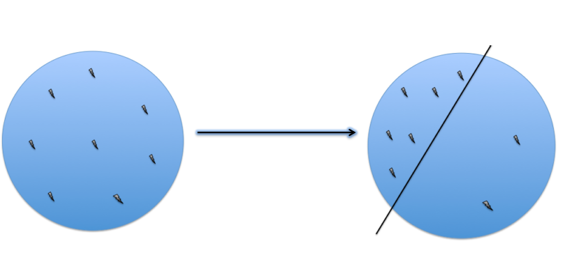

### Introducing coR-ge

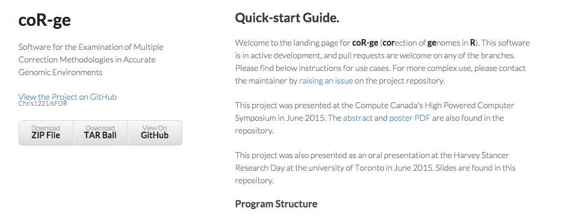

- Software for the Examination of Multiple Correction Methodologies in Accurate Genomic Environments
- Permutation testing of correction methodologies in different settings

### Introducing coR-ge

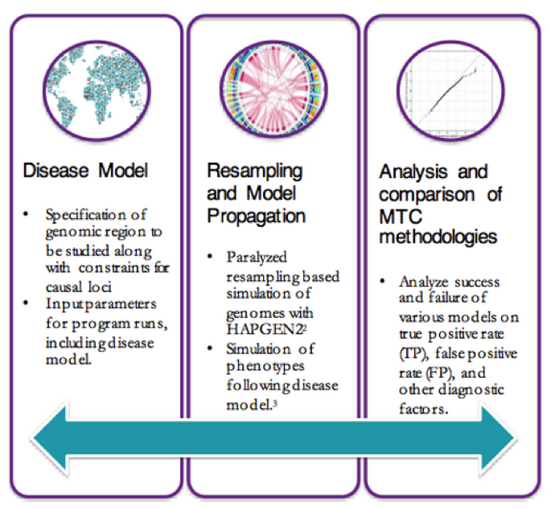

- ~5k lines R, Py, Sh
- Released under GPL
- Requires
  - Cluster
  - Reference Data
  - Causal SNPs
  - etc.

### Disease Model

- Heritability
  - 0.45
- Variability
  - 0.55
- Disease SNPs or loci
- Region of the genome
  - Chromosome 1
- Reference Panel
  - CEU 1000G

### Resampling

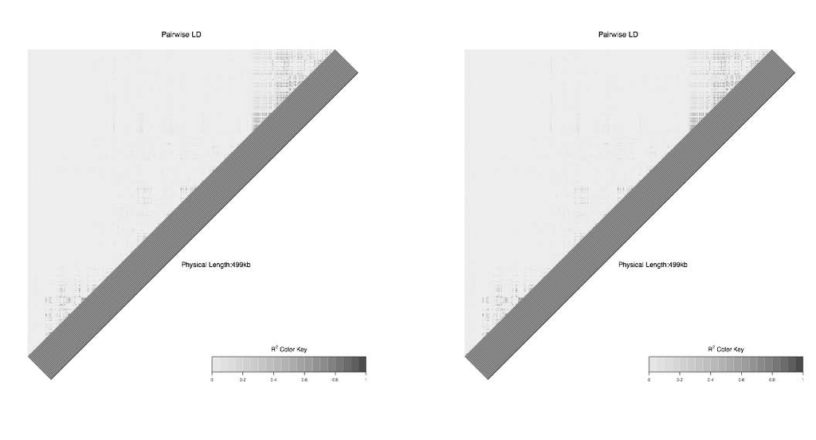

- **HapGen2**
  - Take haplotypes from reference panel
  - Estimate fine-scale recombination rate

### Phenotype Generation

- Effect size for each \( i \) of \( N \) SNPs \( \beta = \delta\sqrt{\frac{\theta^2_i}{2p(1-p)}} \)
  - \( \beta \) effect size in s.d., \( \theta^2_i \) variance, \( p = MAF \), \( \delta = \pm 1 \)
- Risk score \( WAS = \sum_{i=1}^{N} \beta_i SNP_i -2\beta_i p_i \)
  - \( i \) of \( N \) SNPs, \( \beta \) E.S., \( p=MAF \)
- Overall \( z \)-score \( = WAS + N(0,1-h^2) \)
  - \( WAS \) weighted allele score, Gaussian noise \( \mu = 0 \), \( \theta^2 = 1-heritability \)

### Analysis

- Standard GWAS with `plink`, data manipulation in `gtool` and R
- Algorithmic analysis of each permutation
- Reports \( TP_m \), \( FP_m \), \( TN_m \), and \( FN_m \) given \( m \) methodology
- Permuted to establish trends
  - \( n = 100 \)

### Results

- [https://plot.ly/~ChrisCole/58/number-of-true-positives-identified/](https://plot.ly/%7EChrisCole/58/number-of-true-positives-identified/)
- [https://plot.ly/~ChrisCole/70/true-positive-improvement-with-sfdr/](https://plot.ly/%7EChrisCole/70/true-positive-improvement-with-sfdr/)
- [https://plot.ly/~ChrisCole/85/difference-in-false-positives-identified/](https://plot.ly/%7EChrisCole/85/difference-in-false-positives-identified/)
- [https://plot.ly/~ChrisCole/40/average-difference-in-true-positives-with-maf/](https://plot.ly/%7EChrisCole/40/average-difference-in-true-positives-with-maf/)
- [https://plot.ly/~ChrisCole/75/false-positive-inflation-vs-pathway-enrichment/](https://plot.ly/%7EChrisCole/75/false-positive-inflation-vs-pathway-enrichment/)

### Discussion

- We have demonstated sFDR to displaye less false positives with more true positives than aggregated FDR.
- Even in realistic case, more \( TP \), less \( FP \).
- Inflation of \( FP \) in strata is a function of pathway enrichment
- Novel methedology requires a hard second look as a contender
- Lends credibility to the use of sFDR in HD-GWAS

### Future Directions

- Mathematical concequences of genomic dependency on multiplicity control
  - Dr. Lei Sun
- Specific use cases
  - Use same reference panel and set of SNPs
- Improve documentation of **coR-ge**
- Larger and more complex disease models.

### Acknowledgements

- Dr. Jo Knight
- Students / mentors from CAMH
- Hartmut Shmieder
- Institute of Medical Science SURP program
- University of Ottawa Co-op Program
- 1000 Genomes / rOpenSci / R core team
  - etc.

### This presentation

- Slides
  - RMarkdown -> Markdown / PanDocs -> Knitr -> ioslides
  - MathJax / LaTeX
  - Hosted on github
- Plots
  - D3.js -> htmlwidgets -> ggplot2 / ggvis -> plot.ly -> iframes
  - API and server provided by plot.ly